# NBA Data Visualization Project

Author

Antonio Flores

Published

December 7, 2023

# Introduction

Myself and a team performed data analysis on several NBA datasets to identify key trends and relationships between different factors that lead to winning.

This was during my first semester of my Graduate Studies at UTSA in the Fall of 2023.

My largest contribution was in regard to identifying the right data sources, extracting the key variables, aggregating the key tables into single data files, and finally, cleaning the data into usable formats with R.

# Datasets Utilized and Tools

We mainly used R running on Rstudio, Tableau, and Excel for some of the data cleaning portions of this project.

Our data came from  
[Basketball-Reference](https://www.basketball-reference.com/leagues/NBA_2023_totals.html)  
[Cleaning The Glass](https://cleaningtheglass.com/stats/league/summary)

We used tables that included Player, Team, and Shooting data. The most recent season data was for the 2022-2023 NBA season.

# Methods

Our approach to this project included:  
Breaking down the Conferences: East vs. West differences  
Analyzing the effects of Offensive vs Defensive metrics on wins  
Drilling down to variables that impact offensive win shares  
Highlighting the players and the metrics that distinguish their performance & impact on wins

# Results

## Conference Differences

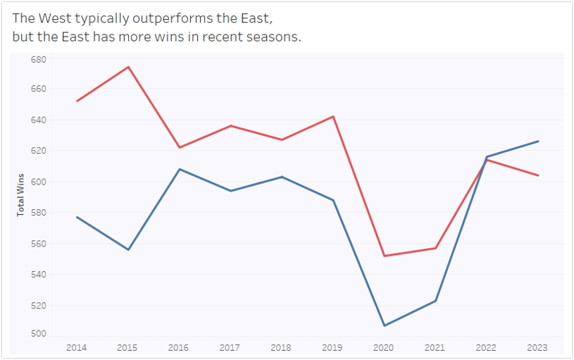

From 2014 to 2021, the Western conference had more wins than the Eastern conference.

In 2022 the East ended the season with 2 more wins than the West and widened this gap in the following year to 22 more wins.

Two seasons may not indicate a true pattern, but the disruption of the West’s dominance is noteworthy.

Teams from the West used to have more wins than losses. Recent years have seen that shift somewhat, with some of the top teams coming from the East

Both points have been attributed by some to the decline in two major Dynasties from the West, San Antonio and Los Angeles.

Ultimately, the distinction between East and West is less meaningful than it’s been in the past.

## Offense vs Defense

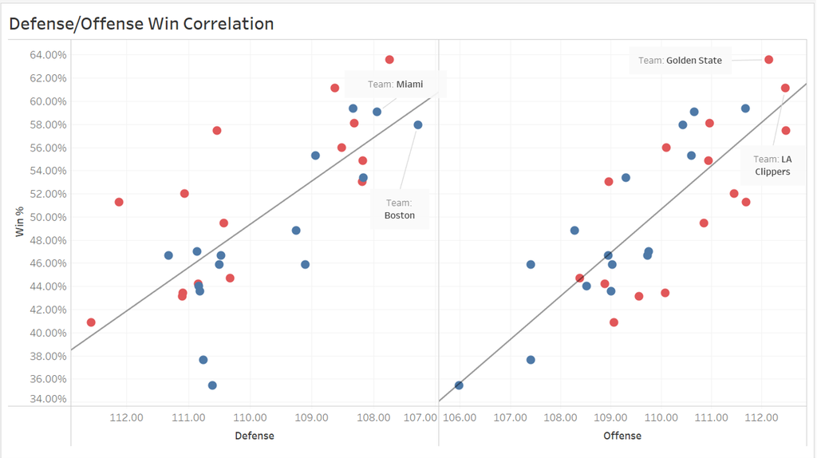

Average Defensive and Offensive points per team for the past 10 seasons. Derived from average points allowed and scored, respectively.

Defensive and Offensive metrics both lead to higher win percentage, with offense being more closely correlated than defense.

## Shooting

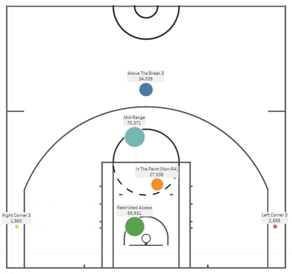

## Player/Position Stats

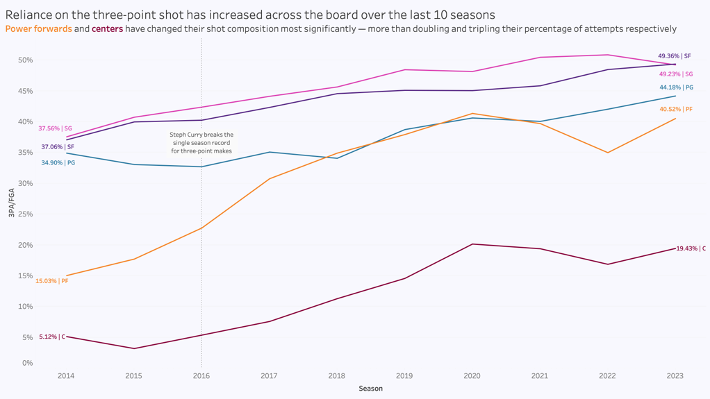

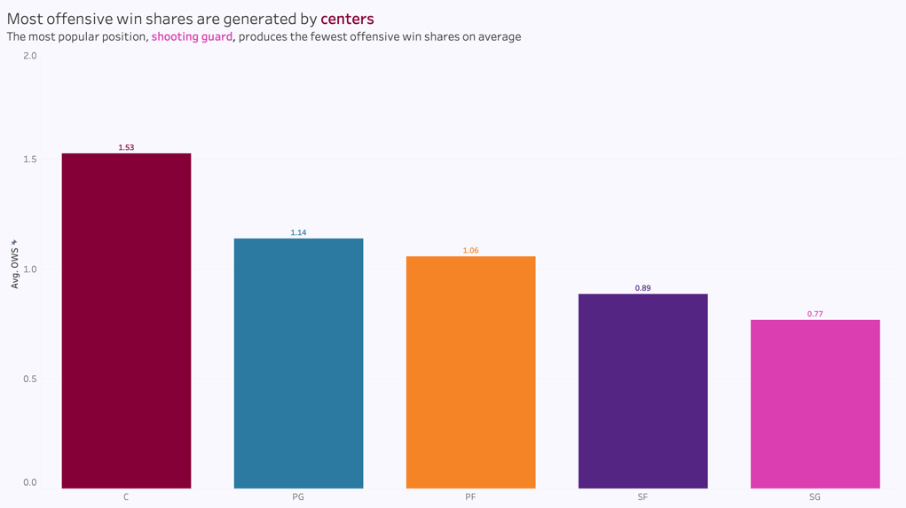

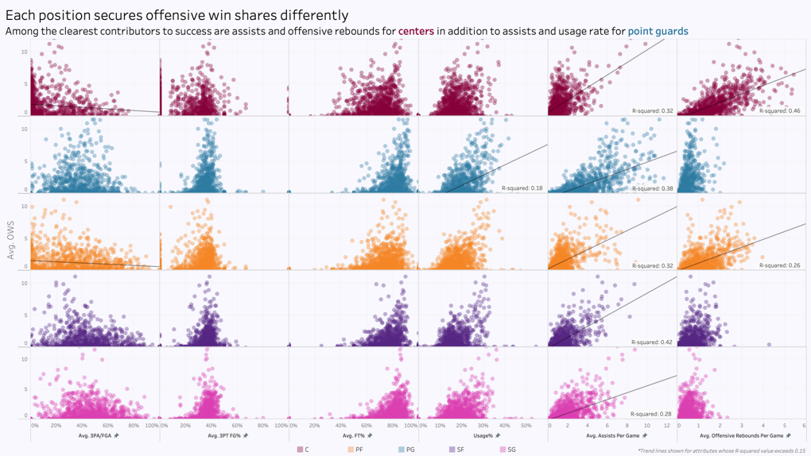

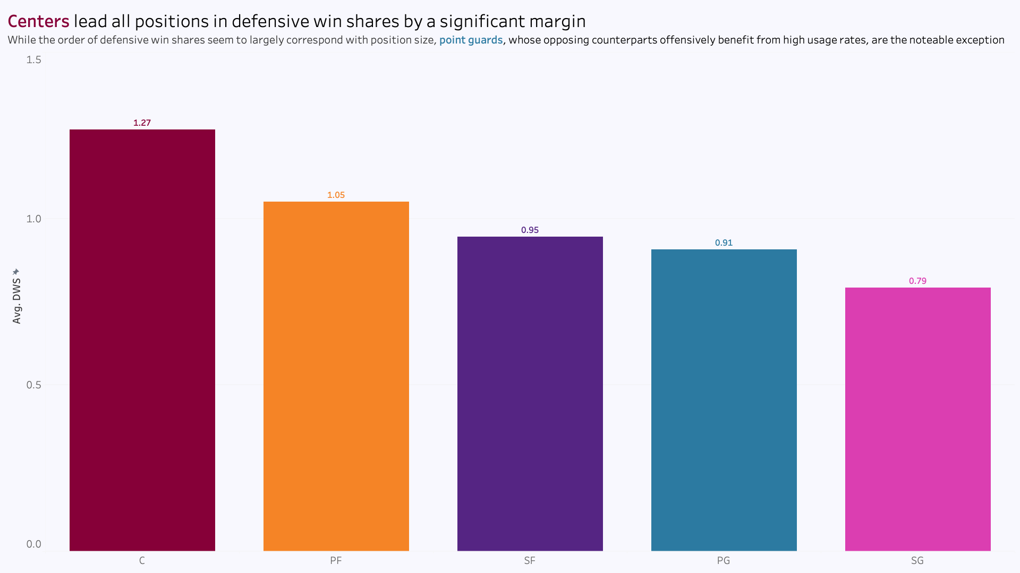

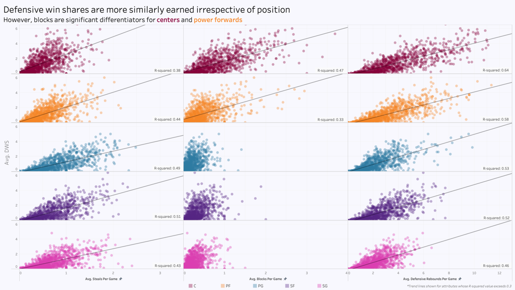

## Effective Selection

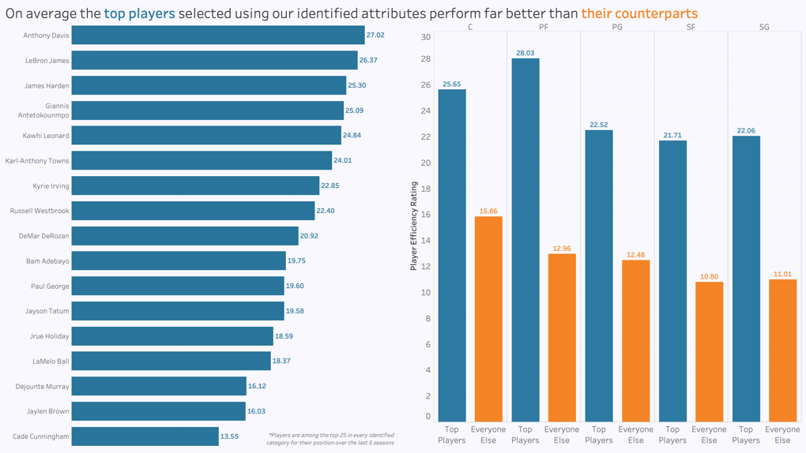

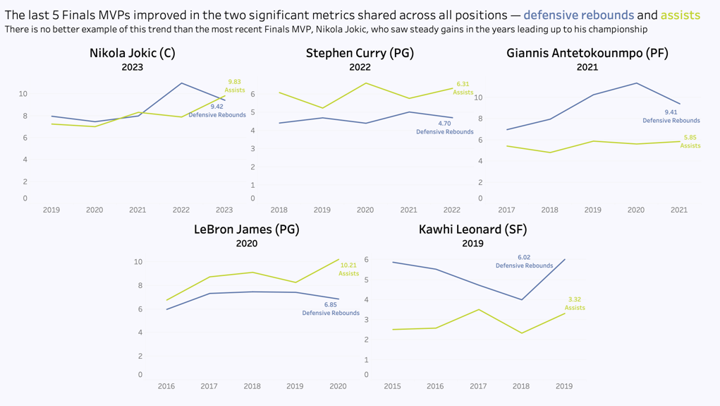

# Conclusions

Ultimately, the distinction between East & West is less meaningful than it’s been in the past.

Defensive and Offensive metrics both lead to higher win percentage, with offense being more closely correlated than defense.

Most offensive and defensive win shares are generated by centers.

On average the top player’s efficiency ratings are higher than the rest of the league.